# JSC370H1 - Lab 04

## 4.

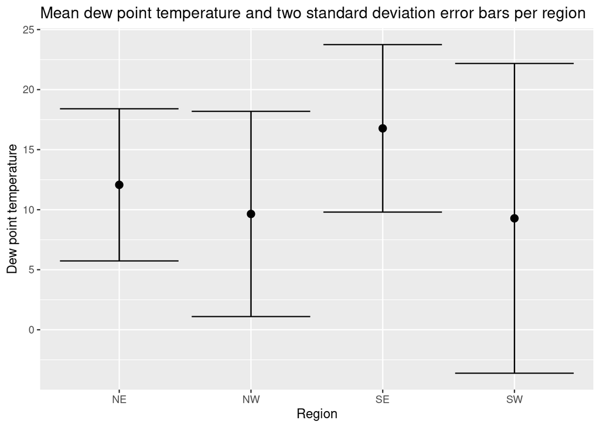

```r
# Use stat_summary() to examine mean dew point and wind speed by region
met_avg %>%
  ggplot(aes(x=region, y=mean_dew_point)) +
  stat_summary(fun.data="mean_sdl", na.rm=TRUE) +
  stat_summary(fun.data="mean_sdl", geom="errorbar") +
  labs(title="Mean dew point temperature and two standard deviation error bars per region",
       x="Region",
       y="Dew point temperature")
```

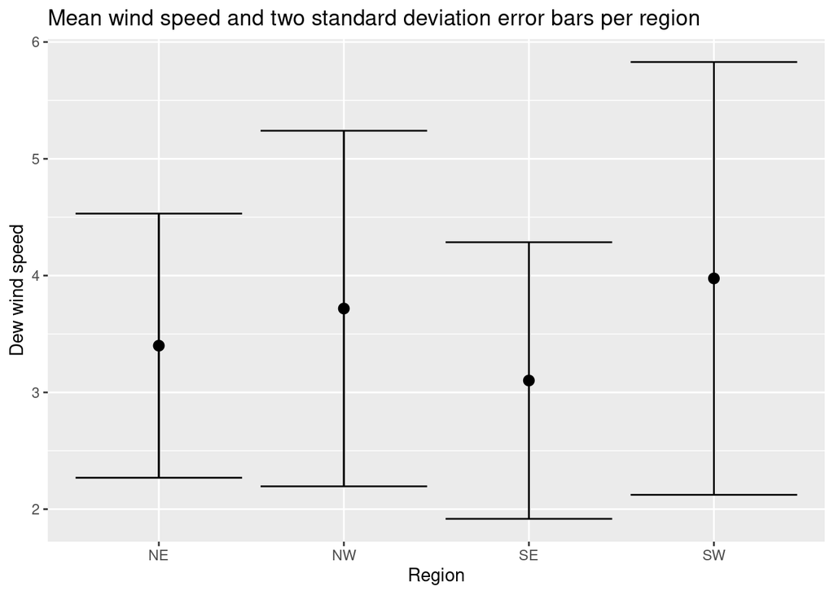

```r
met_avg %>%
  ggplot(aes(x=region, y=mean_wind_sp)) +
  stat_summary(fun.data="mean_sdl", na.rm=TRUE) +
  stat_summary(fun.data="mean_sdl", geom="errorbar") +
  labs(title="Mean wind speed and two standard deviation error bars per region",
       x="Region",
       y="Dew wind speed")
```

The mean of mean dew point temperature is highest for the SE region and lowest for SW. The SW region has the widest error bars of all regions, indicating large variation in its temperature values.

The mean of mean wind speed is highest for the SW region and lowest for the SE region. The SW region, again,has the widest error bars. This is reasonable since the region is predominantly desert and dry, meaning that wind speed and temperature likely fluctuates greatly. Overall, the range of wind speeds for all four regions overlap significantly, more so than for dew point temperature.

## 5.

```r
# Leaflet map showing the spatial trend in relative humidity
pal <- colorNumeric(palette = c("green", "blue"), domain = met_avg$mean_rh)

markers <- met_avg %>%
  arrange(desc(mean_rh)) %>%
  top_n(10, mean_rh)

met_avg %>%
  filter(!is.na(mean_rh)) %>%
  leaflet() %>%
  addTiles() %>%
  addCircles(lng=~mean_lon, lat=~mean_lat, color=~pal(mean_rh)) %>%
  addLegend("bottomleft", pal = pal, values = ~mean_rh,
            title = "Mean relative humidity (%)", opacity = 1) %>%
  addMarkers(lng=markers$mean_lon, lat=markers$mean_lat)
```

[interactive chart not shown]

Mean relative humidity is highest on the coasts of California (SW region) and the SE region, plus a narrow stretch of regions in Texas and upwards. It is lowest in the desert areas of California, New Mexico, and neighboring states (SW region). The Great Lakes region has moderate relative humidity (around 50%). The top ten humid stations are mostly located on a coast, with the notable exception of a station in New Mexico.

## 6.

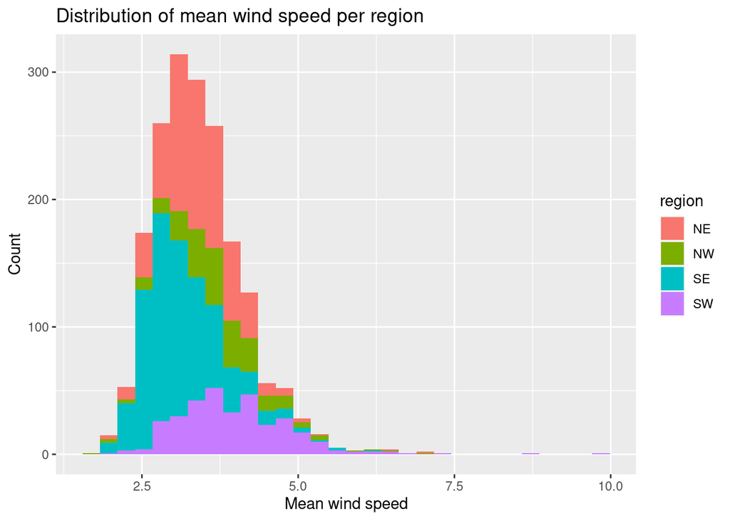

```r
# Using the ggtech library
devtools::install_github("ricardo-bion/ggtech", dependencies=TRUE)
library(ggtech)

qplot(data = met_avg, x = mean_wind_sp, geom = "histogram",
      bins=30, fill = region) +
  labs(title="Distribution of mean wind speed per region",
       x="Mean wind speed",
       y="Count")
```